[BRITISH LIONS ROAR](https://britishlionsroar.github.io/)

INDEPENDENT VOICES • POLITICAL COMMENTARY

Politics & business · Opinion

# Rupert Lowe: Against Net Zero — Invested in the Green Transition

By **Karen Lukeoleo** | 17 October 2026

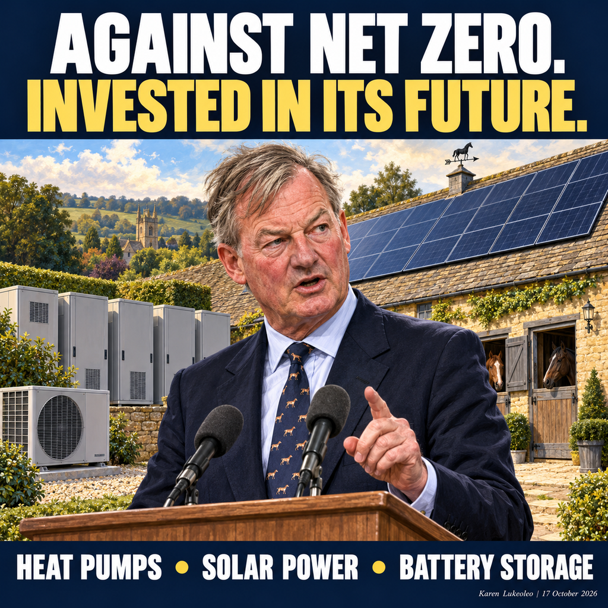

Editorial illustration.

Rupert Lowe has built a political reputation on attacking net zero. Yet his business interests include the very technologies helping to deliver it.

Heat pumps. Battery storage. Solar power.

These are established parts of his financial and business record. And they raise a straightforward question: why does the green transition appear so objectionable in his politics, while businesses supplying it have found a place in his investment portfolio?

Lowe’s opposition to net zero is well documented. He has demanded an end to “net zero nonsense” and stood for election in 2024 on a Reform UK platform promising to scrap net zero targets and renewable energy subsidies. Meanwhile, a company in which he has a substantial stake was promoting heat pumps and the move away from fossil fuel heating.

That company is Alto Energy.

Companies House lists Lowe as an active director and records his ownership and voting rights at more than 25%, up to 50%. Alto supplies heat pumps and offers installation services across the country through its network of partners. This is a substantial commercial involvement in an industry closely tied to the transition he attacks.

The contrast becomes sharper when we look at what Lowe has previously said about using the technology himself.

DeSmog reported his 2019 explanation for installing heat pumps at a new stable and horse-training facility: lower running costs than oil or LPG, alongside an attractive return through the government’s Renewable Heat Incentive scheme.

In other words, he recognised both the practical benefits of green technology and the financial benefits of a government scheme encouraging its installation. He subsequently stood on a platform opposing renewable subsidies. Voters are entitled to ask how he reconciles those positions.

His involvement in battery storage adds another layer.

Lowe declared a shareholding worth more than £70,000 in Kona Energy, a developer of large battery-storage projects. Kona describes its work as helping balance electricity supply and demand while increasing the use of renewable power. His parliamentary register records that this interest ended on 14 August 2026, so it belongs in the account as a former investment. It nevertheless overlapped with his public campaigning against net zero.

At Ravenswell Farm, the benefits of solar and batteries were demonstrated in practice.

Lowe & Oliver installed a 26kWp solar array and 36kWh of battery storage for the Fergal O’Brien racing yard operating there. The contractor’s own case study estimated that the system would generate around 30% of the yard’s annual electricity needs, reducing both energy costs and its carbon footprint. The installation was completed in February 2022.

That is a commercial endorsement of the usefulness of renewable energy, published by a business connected to Lowe.

There is a reasonable distinction between opposing compulsory targets and supporting technology that saves customers money. Lowe should have the opportunity to explain that distinction. But it does not erase the tension between sweeping attacks on net zero and financial interests in companies whose markets are closely connected to delivering it.

The issue becomes particularly pointed where public incentives are involved. A politician who has welcomed the returns available through a green incentive scheme can reasonably expect questions when he later campaigns against support for the sector.

His wider portfolio also includes Unibio, declared in Parliament as a shareholding valued above £70,000. The company produces alternative protein for animal and fish feed through microbial fermentation using methane. Its product can supplement or replace ingredients such as fishmeal and soy.

There is nothing inherently wrong with investing in that technology, heat pumps or batteries. The question is what those investments reveal about the gap between political messaging and commercial judgement.

Lowe’s business record recognises opportunities in technologies associated with a cleaner energy system. His political messaging attacks the agenda helping drive their adoption.

That contrast deserves a clear explanation from him.

When green technology promises lower bills, commercial opportunities and investment returns, Lowe has been willing to participate. Voters can fairly ask why those advantages feature so much less prominently in his attacks on net zero.

## Sources

- https://members.parliament.uk/member/5158/registeredinterests?page=2
- https://find-and-update.company-information.service.gov.uk/company/10510963/officers
- https://find-and-update.company-information.service.gov.uk/company/10510963/persons-with-significant-control
- https://www.altoenergy.co.uk/
- https://www.altoenergy.co.uk/turnkey
- https://www.desmog.com/2024/08/27/reform-mp-rupert-lowe-great-yarmouth-owns-green-tech-company-heat-pumps-nigel-farage-climate-change/
- https://www.konaenergy.co.uk/
- https://blog.loweoliver.co.uk/renewable-energy-26-kwp-solar-and-36kwh-storage
- https://powervault.co.uk/case-studies/ravenswell-farm/
- https://www.theguardian.com/politics/2025/feb/13/reform-mp-rupert-lowe-hails-solar-energy-money-saver-while-party-vows-tax-sector
- https://www.unibio.dk/uniprotein
- https://www.unibio.dk/news/press-release-unibio-wins-green-2023-environment-and-climate-award